# Does your Gender or Steps Walked Affect Your Screen Time?

Author

Ben, James, Chidera

Published

July 15, 2025

## Introduction

Does the amount of steps somebody walks per day influence the amount of screen time they have per day, and does gender have an influence? In short, no. We created a simple survey to ask people for their screen time, steps taken per day, and gender, and created an ANCOVA model to investigate. Let’s walk through how we put it together, the data and model, and how we came to our conclusion.

## Hypothesis

The null hypothesis for the design is that, after accounting for differences in step count, there is no difference in mean screen time between genders. The alternative hypothesis is that, after accounting for differences in step count, there is a difference in mean screen time between genders.

$$\begin{aligned}
H_0 &: \mu_{\text{male}} = \mu_{\text{female}} \quad \text{(no difference in screen time across gender accounting for steps)} \\
H_A &: \mu_{\text{male}} \ne \mu_{\text{female}} \quad \text{(screen time differs by gender accounting for steps)}
\end{aligned}$$

### Alpha

An alpha level of 0.05 was selected to reflect a conventional significance threshold, as neither Type I nor Type II errors were deemed to carry substantially greater consequences in the context of this study.

$$\alpha = 0.05$$

## Methods

We (James, Chidera, and Ben) created an online Google Form survey (link) to collect responses from individuals within our respective friend groups. The survey asked three questions:

```
"What is your gender?"

"What was your screen time on Wednesday, July 9th? (Hours)"

"How many steps did you walk on Wednesday, July 9th?"
```

Screen time responses were reported in hours and later converted to minutes for consistency and analysis. The survey was distributed on Thursday, July 10th, one day after the date in question. While the survey was retrospective, the questions were very simple so we believe this timing did not compromise the accuracy of responses. In total, 13 individuals participated — 7 males and 6 females — which provided a sufficient sample size for our analysis.

While self-reported data cannot be independently verified, we believe the responses are reasonably reliable. The questions were simple and factual, and because participants were volunteers from our personal networks, they had no clear incentive to misreport their screen time or step counts.

It is also worth noting that participants who chose to respond likely had access to step-tracking devices or apps. As a result, they may represent a more active subgroup than the general population, potentially biasing the step count data upward and limiting generalizability.

```r
pacman::p_load(tidyverse,dplyr,car,emmeans,readr,purrr,broom,mosaic,pander,ggplot2,plotly,lubridate,vroom,patchwork)
```

```r
ss <- read.csv("Screentime_Steps.csv")
ss$Steps <- gsub(",", "", ss$Steps)      # Remove commas
ss$Steps <- as.numeric(ss$Steps)         # Convert to numeric
```

```r
View(ss)
glimpse(ss)
```

# Data

Let’s take a look at the data. Screen time was surveyed in hours, but converted to minutes.

```r
ss %>%
  knitr::kable(caption = "Survey Responses")
```

Survey Responses

| Gender | Screentime | Steps |
| --- | --- | --- |
| Male | 497 | 1920 |
| Female | 480 | 6144 |
| Female | 170 | 1663 |
| Male | 300 | 3500 |
| Male | 690 | 7414 |
| Male | 210 | 12000 |
| Female | 270 | 7554 |
| Male | 402 | 19311 |
| Male | 702 | 4345 |
| Female | 330 | 4495 |
| Male | 240 | 6000 |
| Female | 240 | 3870 |
| Female | 360 | 12327 |

### Numerical Analysis

The table below shows the sample size, mean, and standard deviation for each group:

```r
ss_summary <- ss %>%
  group_by(Gender) %>%
  summarise(
    N = n(),
    Mean_Screentime = mean(Screentime),
    SD_Screentime = sd(Screentime),
    Mean_Steps = mean(Steps),
    SD_Steps = sd(Steps)
  )

knitr::kable(ss_summary, digits = 2, caption = "Summary of Screen time and Steps by Gender")
```

Summary of Screen time and Steps by Gender

| Gender | N | Mean_Screentime | SD_Screentime | Mean_Steps | SD_Steps |
| --- | --- | --- | --- | --- | --- |
| Female | 6 | 308.33 | 107.59 | 6008.83 | 3689.92 |
| Male | 7 | 434.43 | 203.36 | 7784.29 | 6035.06 |

The standard deviation of screen time was approximately 1.8 hours (108 minutes) for females and 3.4 hours (203 minutes) for males, indicating high variability within each group. For steps, standard deviations were even larger — over 3,600 for females and over 6,000 for males — reflecting a wide range of physical activity levels among participants.

### Graphical Analysis

We can see the distributions of each group, and how each point relates

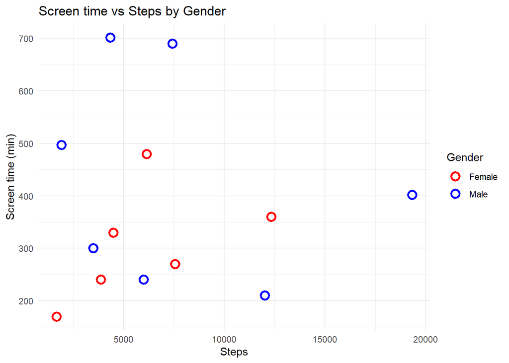

```r
ggplot(ss, aes(x = Steps, y = Screentime, color = Gender)) +
  geom_point(shape = 21, fill = NA, stroke = 1.5, size = 3) +
  scale_color_manual(values = c("Female" = "red", "Male" = "blue")) +
  labs(title = "Screen time vs Steps by Gender",
       x = "Steps", y = "Screen time (min)") +
  theme_minimal()
```

## Assumptions

```r
options(contrasts = c("contr.sum", "contr.sum"))
ancova <- aov(Screentime ~ Steps + Gender, data = ss)
```

```r
model <- ancova

# Extract residuals and fitted values
res <- residuals(model)
fit <- fitted(model)
n <- length(res)

# Residual dataframe (used in p1 and p3)
resid_df <- tibble(
  residuals = res,
  fitted = fit,
  order = 1:n,
  type = if ("Gender" %in% names(ss)) as.character(ss$Gender) else "All"
)

# QQ plot data
d <- tibble(
  x_sample = sort(res),
  z_theoretical = qnorm(ppoints(n))
)

# SE function for QQ bands
se_z <- function(z, n) sqrt((1 + z^2) / (2 * (n - 1)))

# QQ confidence band data
band <- tibble(
  z = seq(-2.2, 2.2, length.out = 300),
  n = n,
  sample_sd = sd(d$x_sample),
  se = sample_sd * se_z(z, n),
  line = mean(d$x_sample) + sample_sd * z,
  upper = line + 2 * se,
  lower = line - 2 * se,
  robust_sd = IQR(d$x_sample) / 1.349,
  robust_line = median(d$x_sample) + z * robust_sd,
  robust_se = robust_sd * se_z(z, n),
  robust_upper = robust_line + 2 * robust_se,
  robust_lower = robust_line - 2 * robust_se
)
```

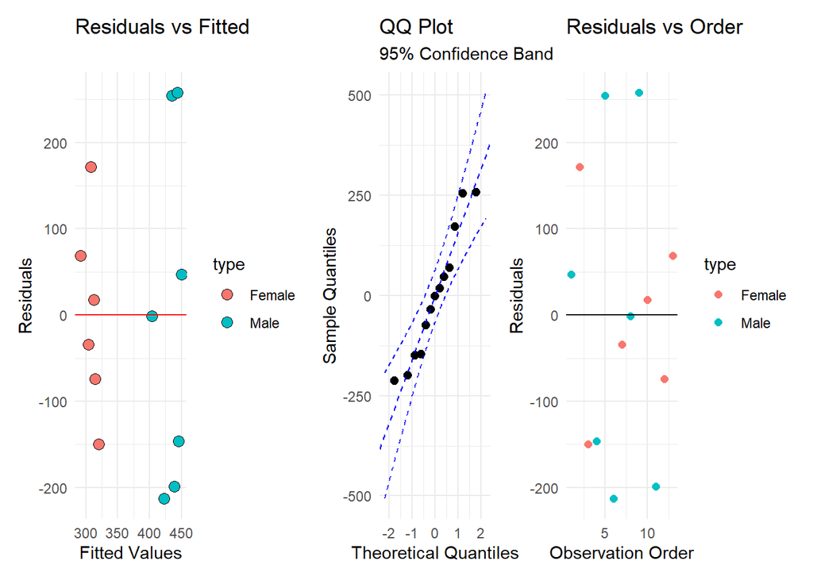

```r
# --- PLOTS ---

# 1. Residuals vs Fitted
p1 <- ggplot(resid_df, aes(x = fitted, y = residuals, fill = type)) +
  geom_point(shape = 21, color = "black", size = 3, stroke = 0.5) +
  geom_hline(yintercept = 0, color = "red") +
  theme_minimal() +
  labs(title = "Residuals vs Fitted", x = "Fitted Values", y = "Residuals")

# 2. QQ Plot
p2 <- ggplot(d) +
  geom_point(aes(x = z_theoretical, y = x_sample), size = 2.2) +
  geom_abline(
    aes(intercept = mean, slope = sd),
    data = tibble(mean = mean(d$x_sample), sd = sd(d$x_sample)),
    linetype = "dashed", color = "blue"
  ) +
  geom_line(aes(x = z, y = upper), data = band, linetype = "dashed", color = "blue") +
  geom_line(aes(x = z, y = lower), data = band, linetype = "dashed", color = "blue") +
  labs(
    x = "Theoretical Quantiles",
    y = "Sample Quantiles",
    title = "QQ Plot",
    subtitle = "95% Confidence Band"
  ) +
  theme_minimal()

# 3. Residuals vs Order
p3 <- ggplot(resid_df, aes(x = order, y = residuals, color = type)) +
  geom_point(size = 2) +
  geom_hline(yintercept = 0, color = "black") +
  theme_minimal() +
  labs(title = "Residuals vs Order", x = "Observation Order", y = "Residuals")

# Combine and show
p1 + p2 + p3
```

### QQ Plot - Normally Distributed Residuals

The QQ plot suggests that the residuals are approximately normally distributed. Although there is a slight S-shaped curve, most points lie close to the reference line and within the confidence bands. Therefore, we consider the normality assumption reasonably satisfied.

### Residuals vs Order - Independent Residuals

We see no patterns or trends in the data, so the requirement for independent residuals is met.

We can run our Anova.

## Anova Model

$$Y_{ij} = \mu + \alpha \cdot x_i + \beta_j + \varepsilon_i$$

Where:

- $Y_{ij}$: Outcome for subject $j$ in group $i$ (e.g., screen time)
- $\mu$: Overall intercept (grand mean)
- $\alpha$: Effect of the covariate (Steps)
- $\beta_j$: Effect of Gender (factor coded as 0 or 1)
- $\varepsilon_{ij}$: Residual error

```r
options(contrasts = c("contr.sum", "contr.sum"))
ancova <- aov(Screentime ~ Steps + Gender, data = ss)
summary(ancova)
```

```
            Df Sum Sq Mean Sq F value Pr(>F)
Steps        1      9       9   0.000  0.987
Gender       1  53451   53451   1.759  0.214
Residuals   10 303913   30391
```

As our P value for Steps, .987 is greater than our alpha of .05, we conclude that Steps does not meaningfully predict Screen Time. After accounting for variation in steps, we find no evidence of a meaningful relationship between physical activity and screen time in our sample. Gender has a p value of 0.214, which — while lower — is still well above our significance threshold. Thus, we also fail to reject the null hypothesis for gender, concluding that screen time does not differ significantly between males and females after accounting for steps.

## Conclusion

Our ANCOVA analysis found no statistically significant effect of either gender or steps walked on screen time. While the average screen time for males was higher than for females, this difference was small relative to the substantial variability within each group. Additionally, the number of steps walked showed no meaningful association with screen time.

Although there was considerable within-group variability, the between-group differences were relatively minor. This, combined with the small sample size, limited our ability to detect statistically significant effects.

Gender and steps don’t seem to explain much about people’s screen time (at least not in our small friend groups), but that doesn’t mean the topic isn’t worth exploring further with more data.